# chapter6

Tiina Siponen

28 11 2019

# Exercise 6

*Work summary* Codes are available at

- https://github.com/tiinasip/IODS-project/blob/master/meet_and_repeat.R

## Data wrangling for both data sets

The data is based on th brief psychiatric rating scale (BPRS) measured before treatment began (week 0) and then at weekly intervals for eight weeks. The BPRS assesses the level of 18 symptom constructs such as hostility, suspiciousness, hallucinations and grandiosity; each of these is rated from one (not present) to seven (extremely severe). The scale is used to evaluate patients suspected of having schizophrenia.

```r
BPRS <- read.table("https://raw.githubusercontent.com/KimmoVehkalahti/MABS/master/Examples/data/BPRS.txt", sep  =" ", header = T)
names(BPRS)
```

```
##  [1] "treatment" "subject"   "week0"     "week1"     "week2"
##  [6] "week3"     "week4"     "week5"     "week6"     "week7"
## [11] "week8"
```

```r
str(BPRS)
```

```
## 'data.frame':    40 obs. of  11 variables:
##  $ treatment: int  1 1 1 1 1 1 1 1 1 1 ...
##  $ subject  : int  1 2 3 4 5 6 7 8 9 10 ...
##  $ week0    : int  42 58 54 55 72 48 71 30 41 57 ...
##  $ week1    : int  36 68 55 77 75 43 61 36 43 51 ...
##  $ week2    : int  36 61 41 49 72 41 47 38 39 51 ...
##  $ week3    : int  43 55 38 54 65 38 30 38 35 55 ...
##  $ week4    : int  41 43 43 56 50 36 27 31 28 53 ...
##  $ week5    : int  40 34 28 50 39 29 40 26 22 43 ...
##  $ week6    : int  38 28 29 47 32 33 30 26 20 43 ...
##  $ week7    : int  47 28 25 42 38 27 31 25 23 39 ...
##  $ week8    : int  51 28 24 46 32 25 31 24 21 32 ...
```

```r
summary(BPRS)
```

```
##    treatment      subject          week0           week1
##  Min.   :1.0   Min.   : 1.00   Min.   :24.00   Min.   :23.00
##  1st Qu.:1.0   1st Qu.: 5.75   1st Qu.:38.00   1st Qu.:35.00
##  Median :1.5   Median :10.50   Median :46.00   Median :41.00
##  Mean   :1.5   Mean   :10.50   Mean   :48.00   Mean   :46.33
##  3rd Qu.:2.0   3rd Qu.:15.25   3rd Qu.:58.25   3rd Qu.:54.25
##  Max.   :2.0   Max.   :20.00   Max.   :78.00   Max.   :95.00
##      week2          week3           week4           week5
##  Min.   :26.0   Min.   :24.00   Min.   :20.00   Min.   :20.00
##  1st Qu.:32.0   1st Qu.:29.75   1st Qu.:28.00   1st Qu.:26.00
##  Median :38.0   Median :36.50   Median :34.50   Median :30.50
##  Mean   :41.7   Mean   :39.15   Mean   :36.35   Mean   :32.55
##  3rd Qu.:49.0   3rd Qu.:44.50   3rd Qu.:43.00   3rd Qu.:38.00
##  Max.   :75.0   Max.   :76.00   Max.   :66.00   Max.   :64.00
##      week6           week7          week8
##  Min.   :19.00   Min.   :18.0   Min.   :20.00
##  1st Qu.:22.75   1st Qu.:23.0   1st Qu.:22.75
##  Median :28.50   Median :30.0   Median :28.00
##  Mean   :31.23   Mean   :32.2   Mean   :31.43
##  3rd Qu.:37.00   3rd Qu.:38.0   3rd Qu.:35.25
##  Max.   :64.00   Max.   :62.0   Max.   :75.00
```

```r
head(BPRS)
```

```
##   treatment subject week0 week1 week2 week3 week4 week5 week6 week7 week8
## 1         1       1    42    36    36    43    41    40    38    47    51
## 2         1       2    58    68    61    55    43    34    28    28    28
## 3         1       3    54    55    41    38    43    28    29    25    24
## 4         1       4    55    77    49    54    56    50    47    42    46
## 5         1       5    72    75    72    65    50    39    32    38    32
## 6         1       6    48    43    41    38    36    29    33    27    25
```

The similar steps are taken with the RATS data. The RATS data is collected in a nutrition study conducted in three groups of rats. The groups were put on different diets, and each animal’s body weight (grams) was recorded repeatedly (approximately) weekly, except in week seven when two recordings were taken) over a 9-week period. The question of most interest is whether the growth profiles of the three groups differ.

From the head & summary of the data it is easy to observe that data is in wide format, in other words there is again a single row for every data point with multiple columns to hold the values of various attributes.

```r
RATS <- read.table("https://raw.githubusercontent.com/KimmoVehkalahti/MABS/master/Examples/data/rats.txt", header = TRUE, sep = '\t')
names(RATS)
```

```
##  [1] "ID"    "Group" "WD1"   "WD8"   "WD15"  "WD22"  "WD29"  "WD36"
##  [9] "WD43"  "WD44"  "WD50"  "WD57"  "WD64"
```

```r
str(RATS)
```

```
## 'data.frame':    16 obs. of  13 variables:
##  $ ID   : int  1 2 3 4 5 6 7 8 9 10 ...
##  $ Group: int  1 1 1 1 1 1 1 1 2 2 ...
##  $ WD1  : int  240 225 245 260 255 260 275 245 410 405 ...
##  $ WD8  : int  250 230 250 255 260 265 275 255 415 420 ...
##  $ WD15 : int  255 230 250 255 255 270 260 260 425 430 ...
##  $ WD22 : int  260 232 255 265 270 275 270 268 428 440 ...
##  $ WD29 : int  262 240 262 265 270 275 273 270 438 448 ...
##  $ WD36 : int  258 240 265 268 273 277 274 265 443 460 ...
##  $ WD43 : int  266 243 267 270 274 278 276 265 442 458 ...
##  $ WD44 : int  266 244 267 272 273 278 271 267 446 464 ...
##  $ WD50 : int  265 238 264 274 276 284 282 273 456 475 ...
##  $ WD57 : int  272 247 268 273 278 279 281 274 468 484 ...
##  $ WD64 : int  278 245 269 275 280 281 284 278 478 496 ...
```

```r
summary(RATS)
```

```
##        ID            Group           WD1             WD8
##  Min.   : 1.00   Min.   :1.00   Min.   :225.0   Min.   :230.0
##  1st Qu.: 4.75   1st Qu.:1.00   1st Qu.:252.5   1st Qu.:255.0
##  Median : 8.50   Median :1.50   Median :340.0   Median :345.0
##  Mean   : 8.50   Mean   :1.75   Mean   :365.9   Mean   :369.1
##  3rd Qu.:12.25   3rd Qu.:2.25   3rd Qu.:480.0   3rd Qu.:476.2
##  Max.   :16.00   Max.   :3.00   Max.   :555.0   Max.   :560.0
##       WD15            WD22            WD29            WD36
##  Min.   :230.0   Min.   :232.0   Min.   :240.0   Min.   :240.0
##  1st Qu.:255.0   1st Qu.:267.2   1st Qu.:268.8   1st Qu.:267.2
##  Median :347.5   Median :351.5   Median :356.5   Median :360.0
##  Mean   :372.5   Mean   :379.2   Mean   :383.9   Mean   :387.0
##  3rd Qu.:486.2   3rd Qu.:492.5   3rd Qu.:497.8   3rd Qu.:504.2
##  Max.   :565.0   Max.   :580.0   Max.   :590.0   Max.   :597.0
##       WD43            WD44            WD50            WD57
##  Min.   :243.0   Min.   :244.0   Min.   :238.0   Min.   :247.0
##  1st Qu.:269.2   1st Qu.:270.0   1st Qu.:273.8   1st Qu.:273.8
##  Median :360.0   Median :362.0   Median :370.0   Median :373.5
##  Mean   :386.0   Mean   :388.3   Mean   :394.6   Mean   :398.6
##  3rd Qu.:501.0   3rd Qu.:510.5   3rd Qu.:516.0   3rd Qu.:524.5
##  Max.   :595.0   Max.   :595.0   Max.   :612.0   Max.   :618.0
##       WD64
##  Min.   :245.0
##  1st Qu.:278.0
##  Median :378.0
##  Mean   :404.1
##  3rd Qu.:530.8
##  Max.   :628.0
```

```r
head(RATS)
```

```
##   ID Group WD1 WD8 WD15 WD22 WD29 WD36 WD43 WD44 WD50 WD57 WD64
## 1  1     1 240 250  255  260  262  258  266  266  265  272  278
## 2  2     1 225 230  230  232  240  240  243  244  238  247  245
## 3  3     1 245 250  250  255  262  265  267  267  264  268  269
## 4  4     1 260 255  255  265  265  268  270  272  274  273  275
## 5  5     1 255 260  255  270  270  273  274  273  276  278  280
## 6  6     1 260 265  270  275  275  277  278  278  284  279  281
```

In BPRS, categorical datasets are created and week variable is created to show the week numbers

```r
library(dplyr)
library(tidyr)
BPRS$treatment <- factor(BPRS$treatment)
BPRS$subject <- factor(BPRS$subject)
# Convert to long form
BPRSL <-  BPRS %>% gather(key = weeks, value = bprs, -treatment, -subject)
# Extract the week number
BPRSL <-  BPRSL %>% mutate(week = as.integer(substr(weeks,5,5)))
# glimpse at the BPRSL data
glimpse(BPRSL)
```

```
## Observations: 360
## Variables: 5
## $ treatment <fct> 1, 1, 1, 1, 1, 1, 1, 1, 1, 1, 1, 1, 1, 1, 1, 1, 1, 1...
## $ subject   <fct> 1, 2, 3, 4, 5, 6, 7, 8, 9, 10, 11, 12, 13, 14, 15, 1...
## $ weeks     <chr> "week0", "week0", "week0", "week0", "week0", "week0"...
## $ bprs      <int> 42, 58, 54, 55, 72, 48, 71, 30, 41, 57, 30, 55, 36, ...
## $ week      <int> 0, 0, 0, 0, 0, 0, 0, 0, 0, 0, 0, 0, 0, 0, 0, 0, 0, 0...
```

```r
dim(BPRSL)
```

```
## [1] 360   5
```

```r
str(BPRSL)
```

```
## 'data.frame':    360 obs. of  5 variables:
##  $ treatment: Factor w/ 2 levels "1","2": 1 1 1 1 1 1 1 1 1 1 ...
##  $ subject  : Factor w/ 20 levels "1","2","3","4",..: 1 2 3 4 5 6 7 8 9 10 ...
##  $ weeks    : chr  "week0" "week0" "week0" "week0" ...
##  $ bprs     : int  42 58 54 55 72 48 71 30 41 57 ...
##  $ week     : int  0 0 0 0 0 0 0 0 0 0 ...
```

Now BPRS data is in the long format. In the long format, for each data point, there are as many rows as the number of attributes and each row contains the value of a particular attribute for a given data point.

In RATS, categorical datasets are created and Time variable is created to show the week numbers. The similar change from wide format to long format is visible. There are now 5 variables and 176 observations. In the wide format, there were 16 rows and 13 columns. The weeknumbers are now attribute for the data point.

```r
RATS$ID <- factor(RATS$ID)
RATS$Group <- factor(RATS$Group)
# Convert data to long form
RATSL <- RATS %>%
  gather(key = WD, value = Weight, -ID, -Group) %>%
  mutate(Time = as.integer(substr(WD,3,4)))
# Glimpse the data
glimpse(RATSL)
```

```
## Observations: 176
## Variables: 5
## $ ID     <fct> 1, 2, 3, 4, 5, 6, 7, 8, 9, 10, 11, 12, 13, 14, 15, 16, ...
## $ Group  <fct> 1, 1, 1, 1, 1, 1, 1, 1, 2, 2, 2, 2, 3, 3, 3, 3, 1, 1, 1...
## $ WD     <chr> "WD1", "WD1", "WD1", "WD1", "WD1", "WD1", "WD1", "WD1",...
## $ Weight <int> 240, 225, 245, 260, 255, 260, 275, 245, 410, 405, 445, ...
## $ Time   <int> 1, 1, 1, 1, 1, 1, 1, 1, 1, 1, 1, 1, 1, 1, 1, 1, 8, 8, 8...
```

```r
dim(RATSL)
```

```
## [1] 176   5
```

```r
str(RATSL)
```

```
## 'data.frame':    176 obs. of  5 variables:
##  $ ID    : Factor w/ 16 levels "1","2","3","4",..: 1 2 3 4 5 6 7 8 9 10 ...
##  $ Group : Factor w/ 3 levels "1","2","3": 1 1 1 1 1 1 1 1 2 2 ...
##  $ WD    : chr  "WD1" "WD1" "WD1" "WD1" ...
##  $ Weight: int  240 225 245 260 255 260 275 245 410 405 ...
##  $ Time  : int  1 1 1 1 1 1 1 1 1 1 ...
```

```r
head(RATSL)
```

```
##   ID Group  WD Weight Time
## 1  1     1 WD1    240    1
## 2  2     1 WD1    225    1
## 3  3     1 WD1    245    1
## 4  4     1 WD1    260    1
## 5  5     1 WD1    255    1
## 6  6     1 WD1    260    1
```

## Analysis - BPRSL

### Plots to analyse data

The object of the analysis is to use linear mixed effects models to BPRSL data. First it adviced to join points belonging to each patient and draw a plot to see, are individual measure points independent.

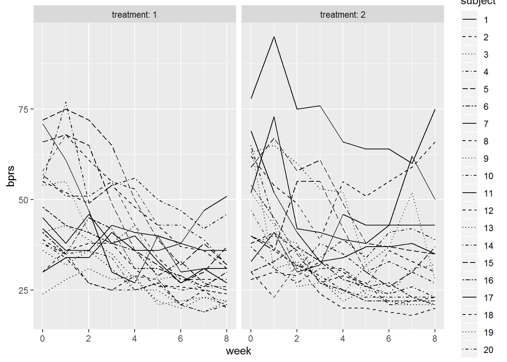

```r
library(ggplot2)
ggplot(BPRSL, aes(x = week, y = bprs, linetype = subject)) +
  geom_line() +
  scale_linetype_manual(values = rep(1:10, times=4)) +
  facet_grid(. ~ treatment, labeller = label_both) +
  theme(legend.position = "right") +
  scale_y_continuous(limits = c(min(BPRSL$bprs), max(BPRSL$bprs)))
```

Individuals, who have high values in the beginning, tend to have higher values also at the end. Therefore I standardize the points to be able to see more clearly tracking by treatment. In standardization, the mean is 0. Now the plots are different, and it is not obvious, whether the treatment decreases the points compared to the starting time.

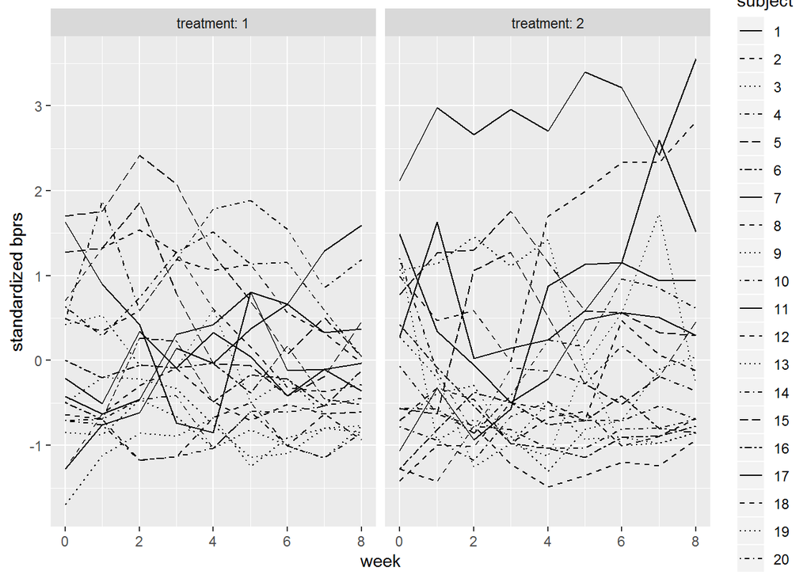

```r
library(dplyr)
library(tidyr)
library(ggplot2)
BPRSL <- BPRSL %>%
  group_by(week) %>%
  mutate(stdbprs = (bprs - mean(bprs))/sd(bprs) ) %>%
  ungroup()
ggplot(BPRSL, aes(x = week, y = stdbprs, linetype = subject)) +
  geom_line() +
  scale_linetype_manual(values = rep(1:10, times=4)) +
  facet_grid(. ~ treatment, labeller = label_both) +
  scale_y_continuous(name = "standardized bprs")
```

### Simple linear model

The explanatory variables are treatment and week.

Simple linear model is created for comparison. Multiple R-squares is 0.1851, P value is significat for the week. This is not valid modelling, because it assumes independence of the repeated measures of bprs - but this is not likely.

```r
simple_linear_model <- lm(bprs ~ treatment + week, data = BPRSL)
summary(simple_linear_model)
```

```
##
## Call:
## lm(formula = bprs ~ treatment + week, data = BPRSL)
##
## Residuals:
##     Min      1Q  Median      3Q     Max
## -22.454  -8.965  -3.196   7.002  50.244
##
## Coefficients:
##             Estimate Std. Error t value Pr(>|t|)
## (Intercept)  46.4539     1.3670  33.982   <2e-16 ***
## treatment2    0.5722     1.3034   0.439    0.661
## week         -2.2704     0.2524  -8.995   <2e-16 ***
## ---
## Signif. codes:  0 '***' 0.001 '**' 0.01 '*' 0.05 '.' 0.1 ' ' 1
##
## Residual standard error: 12.37 on 357 degrees of freedom
## Multiple R-squared:  0.1851, Adjusted R-squared:  0.1806
## F-statistic: 40.55 on 2 and 357 DF,  p-value: < 2.2e-16
```

### Randon Intercept Model and Random Intercept and Random Slope Model

Random Intercept Model is created first. The standard deviation of a subject is 6.89, which is quite high and indicates that the values are spreading. The closer T is to 0, the more likely there isn’t a significant difference. Week’s t-value is high and it indicates relation, but treatment2 is close to zero - seems that it does not have effect on bprs resutls.

```r
library(lme4)
BPRSL_ref <- lmer(bprs ~ week + treatment + (1 | subject), data = BPRSL, REML = FALSE)
summary(BPRSL_ref)
```

```
## Linear mixed model fit by maximum likelihood  ['lmerMod']
## Formula: bprs ~ week + treatment + (1 | subject)
##    Data: BPRSL
##
##      AIC      BIC   logLik deviance df.resid
##   2748.7   2768.1  -1369.4   2738.7      355
##
## Scaled residuals:
##     Min      1Q  Median      3Q     Max
## -3.0481 -0.6749 -0.1361  0.4813  3.4855
##
## Random effects:
##  Groups   Name        Variance Std.Dev.
##  subject  (Intercept)  47.41    6.885
##  Residual             104.21   10.208
## Number of obs: 360, groups:  subject, 20
##
## Fixed effects:
##             Estimate Std. Error t value
## (Intercept)  46.4539     1.9090  24.334
## week         -2.2704     0.2084 -10.896
## treatment2    0.5722     1.0761   0.532
##
## Correlation of Fixed Effects:
##            (Intr) week
## week       -0.437
## treatment2 -0.282  0.000
```

Next Random Intercept and Random Slope Model is created. This model takes into account individual differences in bprs profiles but also the effect of weeks. Subject’s standard deviation is bigger than in Random Intercept Model. The closer T is to 0, the more likely there isn’t a significant difference. Week’s t-value is high and it indicates relation, but treatment2 is close to zero - seems that it does not have effect on bprs resutls.

```r
BPRSL_ref1 <- lmer(bprs ~ week + treatment + (week | subject), data = BPRSL, REML = FALSE)
summary(BPRSL_ref1)
```

```
## Linear mixed model fit by maximum likelihood  ['lmerMod']
## Formula: bprs ~ week + treatment + (week | subject)
##    Data: BPRSL
##
##      AIC      BIC   logLik deviance df.resid
##   2745.4   2772.6  -1365.7   2731.4      353
##
## Scaled residuals:
##     Min      1Q  Median      3Q     Max
## -2.8919 -0.6194 -0.0691  0.5531  3.7977
##
## Random effects:
##  Groups   Name        Variance Std.Dev. Corr
##  subject  (Intercept) 64.8222  8.0512
##           week         0.9609  0.9803   -0.51
##  Residual             97.4304  9.8707
## Number of obs: 360, groups:  subject, 20
##
## Fixed effects:
##             Estimate Std. Error t value
## (Intercept)  46.4539     2.1052  22.066
## week         -2.2704     0.2977  -7.626
## treatment2    0.5722     1.0405   0.550
##
## Correlation of Fixed Effects:
##            (Intr) week
## week       -0.582
## treatment2 -0.247  0.000
```

```r
# perform an ANOVA test on the two models
anova(BPRSL_ref1, BPRSL_ref)
```

```
## Data: BPRSL
## Models:
## BPRSL_ref: bprs ~ week + treatment + (1 | subject)
## BPRSL_ref1: bprs ~ week + treatment + (week | subject)
##            Df    AIC    BIC  logLik deviance  Chisq Chi Df Pr(>Chisq)
## BPRSL_ref   5 2748.7 2768.1 -1369.4   2738.7
## BPRSL_ref1  7 2745.4 2772.6 -1365.7   2731.4 7.2721      2    0.02636 *
## ---
## Signif. codes:  0 '***' 0.001 '**' 0.01 '*' 0.05 '.' 0.1 ' ' 1
```

```r
BPRSL_ref2 <- lmer(bprs ~ week * treatment + (week | subject), data = BPRSL, REML = FALSE)
summary(BPRSL_ref2)
```

```
## Linear mixed model fit by maximum likelihood  ['lmerMod']
## Formula: bprs ~ week * treatment + (week | subject)
##    Data: BPRSL
##
##      AIC      BIC   logLik deviance df.resid
##   2744.3   2775.4  -1364.1   2728.3      352
##
## Scaled residuals:
##     Min      1Q  Median      3Q     Max
## -3.0512 -0.6271 -0.0768  0.5288  3.9260
##
## Random effects:
##  Groups   Name        Variance Std.Dev. Corr
##  subject  (Intercept) 64.9964  8.0620
##           week         0.9687  0.9842   -0.51
##  Residual             96.4707  9.8220
## Number of obs: 360, groups:  subject, 20
##
## Fixed effects:
##                 Estimate Std. Error t value
## (Intercept)      47.8856     2.2521  21.262
## week             -2.6283     0.3589  -7.323
## treatment2       -2.2911     1.9090  -1.200
## week:treatment2   0.7158     0.4010   1.785
##
## Correlation of Fixed Effects:
##             (Intr) week   trtmn2
## week        -0.650
## treatment2  -0.424  0.469
## wek:trtmnt2  0.356 -0.559 -0.840
```

```r
anova(BPRSL_ref2, BPRSL_ref1)
```

```
## Data: BPRSL
## Models:
## BPRSL_ref1: bprs ~ week + treatment + (week | subject)
## BPRSL_ref2: bprs ~ week * treatment + (week | subject)
##            Df    AIC    BIC  logLik deviance  Chisq Chi Df Pr(>Chisq)
## BPRSL_ref1  7 2745.4 2772.6 -1365.7   2731.4
## BPRSL_ref2  8 2744.3 2775.4 -1364.1   2728.3 3.1712      1    0.07495 .
## ---
## Signif. codes:  0 '***' 0.001 '**' 0.01 '*' 0.05 '.' 0.1 ' ' 1
```

A vector of fitted values is created and added to the BPRSL data

```r
Fitted <- fitted(BPRSL_ref2)
BPRSL <- BPRSL %>%
  mutate(Fitted)
```

Next fitted values from the model are plotted. The both treatments show decrease of bprs points over time.

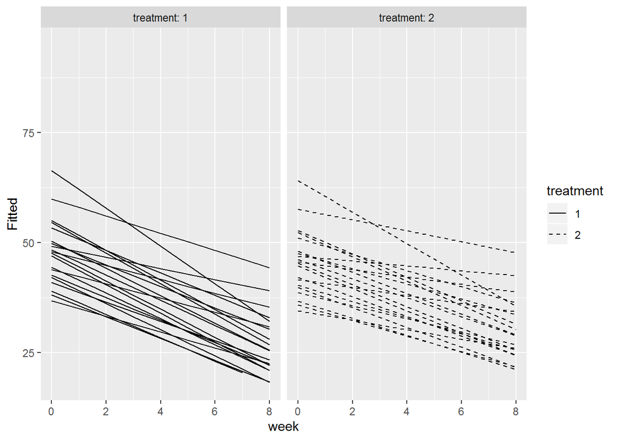

```r
ggplot(BPRSL, aes(x = week, y = Fitted, group= subject, linetype = treatment)) +
  geom_line() +
  scale_linetype_manual(values = rep(1:10, times=4)) +
  facet_grid(. ~ treatment, labeller = label_both) +
  theme(legend.position = "right") +
  scale_y_continuous(limits = c(min(BPRSL$bprs), max(BPRSL$bprs)))
```

Comparison to observed values:

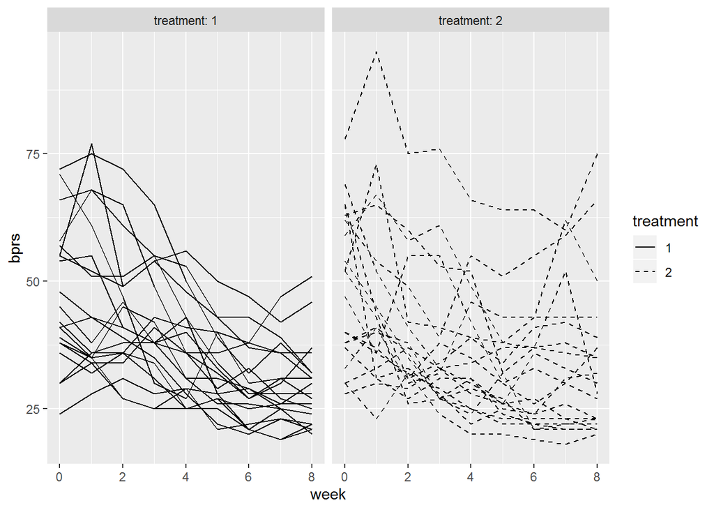

```r
ggplot(BPRSL, aes(x = week, y = bprs, group= subject, linetype = treatment)) +
  geom_line() +
  scale_linetype_manual(values = rep(1:10, times=4)) +
  facet_grid(. ~ treatment, labeller = label_both) +
  theme(legend.position = "right") +
  scale_y_continuous(limits = c(min(BPRSL$bprs), max(BPRSL$bprs)))
```

## Analysis - RATSL

### Tracking effect

The weight development of each mouse is shown in figures below.

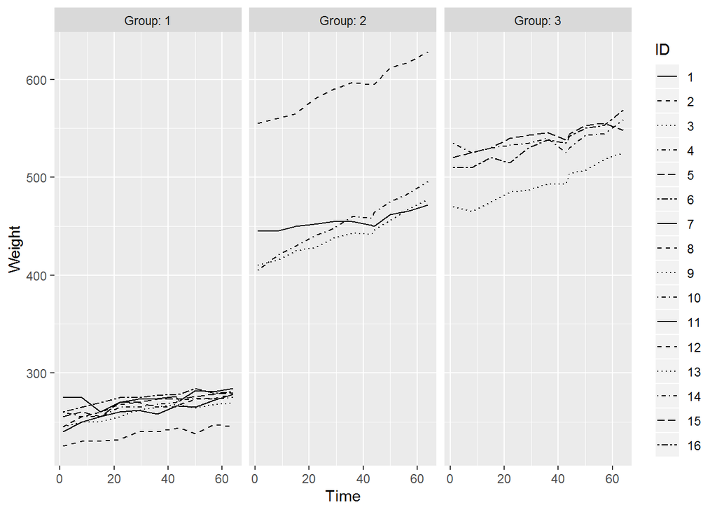

```r
ggplot(RATSL, aes(x = Time, y = Weight, linetype = ID)) +
  geom_line() +
  scale_linetype_manual(values = rep(1:10, times=4)) +
  facet_grid(. ~ Group, labeller = label_both) +
  theme(legend.position = "right") +
  scale_y_continuous(limits = c(min(RATSL$Weight), max(RATSL$Weight)))
```

Individuals, who have high values in the beginning, tend to have higher values also at the end, similary as in BPRS data. Therefore I standardize the weights to be able to see more clearly tracking by groups. In standardization, the mean is 0.

```r
RATSL <- RATSL %>%
  group_by(Time) %>%
  mutate(stdweight = (Weight - mean(Weight))/sd(Weight) ) %>%
  ungroup()
glimpse(RATSL)
```

```
## Observations: 176
## Variables: 6
## $ ID        <fct> 1, 2, 3, 4, 5, 6, 7, 8, 9, 10, 11, 12, 13, 14, 15, 1...
## $ Group     <fct> 1, 1, 1, 1, 1, 1, 1, 1, 2, 2, 2, 2, 3, 3, 3, 3, 1, 1...
## $ WD        <chr> "WD1", "WD1", "WD1", "WD1", "WD1", "WD1", "WD1", "WD...
## $ Weight    <int> 240, 225, 245, 260, 255, 260, 275, 245, 410, 405, 44...
## $ Time      <int> 1, 1, 1, 1, 1, 1, 1, 1, 1, 1, 1, 1, 1, 1, 1, 1, 8, 8...
## $ stdweight <dbl> -1.0011429, -1.1203857, -0.9613953, -0.8421525, -0.8...
```

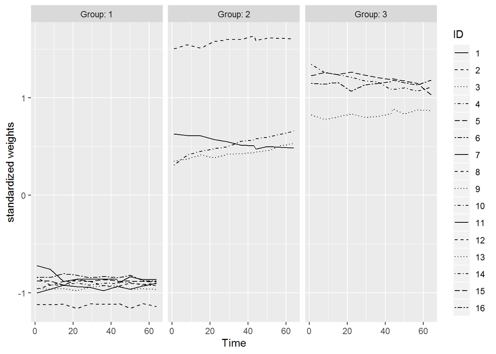

```r
ggplot(RATSL, aes(x = Time, y = stdweight, linetype = ID)) +
  geom_line() +
  scale_linetype_manual(values = rep(1:10, times=4)) +
  facet_grid(. ~ Group, labeller = label_both) +
  scale_y_continuous(name = "standardized weights")
```

### Summary Measure Analysis

Standard error of the mean is calculated next.

```r
n <- RATSL$Time %>% unique() %>% length()
RATSSS <- RATSL %>%
  group_by(Group, Time) %>%
  summarise( mean = mean(Weight), se = sd(Weight)/sqrt(n) ) %>%
  ungroup()
RATSSS$se
```

```
##  [1]  4.589478  3.947710  3.460116  4.100800  3.333956  3.552939  3.302646
##  [8]  3.073768  4.390071  3.243375  3.751190 21.047385 20.486507 19.866982
## [15] 21.311542 21.660430 21.865117 21.898526 21.483433 22.389628 22.044033
## [22] 22.224066  8.382431  8.561276  7.917663  7.399324  7.561365  7.358257
## [29]  6.210329  5.548683  6.407264  5.131601  5.696224
```

```r
glimpse(RATSSS)
```

```
## Observations: 33
## Variables: 4
## $ Group <fct> 1, 1, 1, 1, 1, 1, 1, 1, 1, 1, 1, 2, 2, 2, 2, 2, 2, 2, 2,...
## $ Time  <int> 1, 8, 15, 22, 29, 36, 43, 44, 50, 57, 64, 1, 8, 15, 22, ...
## $ mean  <dbl> 250.625, 255.000, 254.375, 261.875, 264.625, 265.000, 26...
## $ se    <dbl> 4.589478, 3.947710, 3.460116, 4.100800, 3.333956, 3.5529...
```

Mean weight grow profiles are drawn in the next figure. All groups gain wieght, but groups 2 and 3 gain it faster than group 1. Group 2 seems to grow th most, but there are also more variance in it compared to other groups.

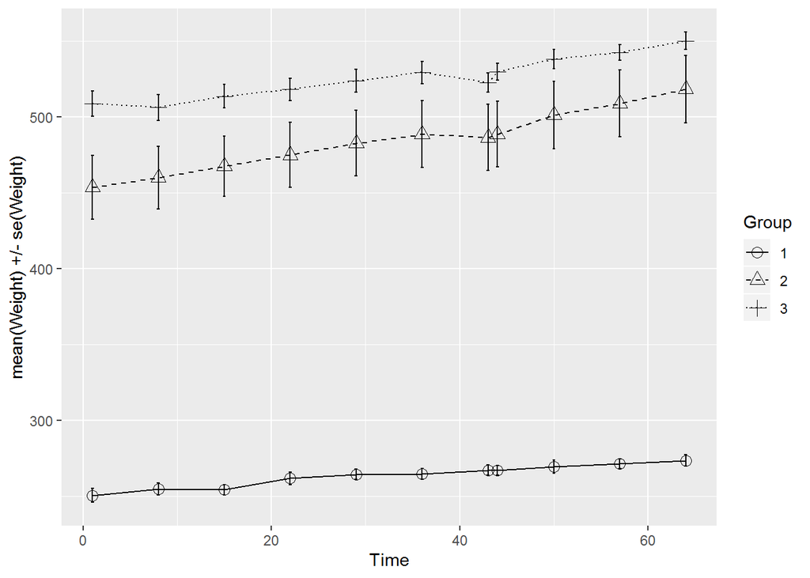

```r
ggplot(RATSSS, aes(x = Time, y = mean, linetype = Group, shape = Group)) +
  geom_line() +
  scale_linetype_manual(values = c(1,2,3)) +
  geom_point(size=3) +
  scale_shape_manual(values = c(1,2,3)) +
  geom_errorbar(aes(ymin = mean - se, ymax = mean + se, linetype="1"), width=0.3) +
  theme(legend.position = "right") +
  scale_y_continuous(name = "mean(Weight) +/- se(Weight)")
```

Means from weeks 8-64 are calculate to check the mean development. The first week (week 1) is left out because it was the starting week and there was not yet any change due to nutrition changes.

```r
RATSSL8S <- RATSL %>%
  filter(Time > 1) %>%
  group_by(Group, ID) %>%
  summarise( mean=mean(Weight))
# Glimpse the data
glimpse(RATSSL8S)
```

```
## Observations: 16
## Variables: 3
## Groups: Group [3]
## $ Group <fct> 1, 1, 1, 1, 1, 1, 1, 1, 2, 2, 2, 2, 3, 3, 3, 3
## $ ID    <fct> 1, 2, 3, 4, 5, 6, 7, 8, 9, 10, 11, 12, 13, 14, 15, 16
## $ mean  <dbl> 263.2, 238.9, 261.7, 267.2, 270.9, 276.2, 274.6, 267.5, ...
```

### Boxplot mean versus treatment

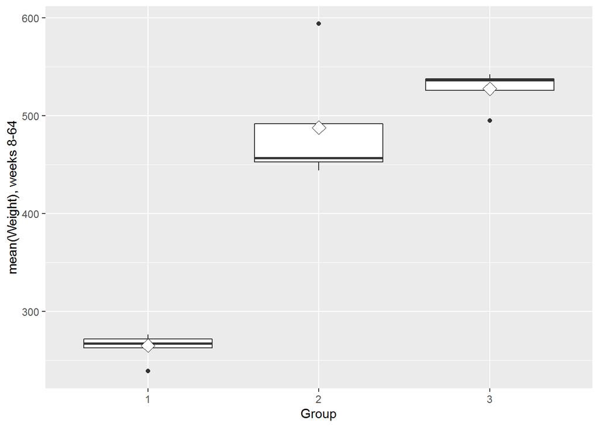

```r
ggplot(RATSSL8S, aes(x = Group, y = mean)) +
  geom_boxplot() +
  stat_summary(fun.y = "mean", geom = "point", shape=23, size=4, fill = "white") +
  scale_y_continuous(name = "mean(Weight), weeks 8-64")
```

There are some outliers in data. Next the outliers are taken away based on the picture above. Both more than 550 and under 250 outliers are excluded.

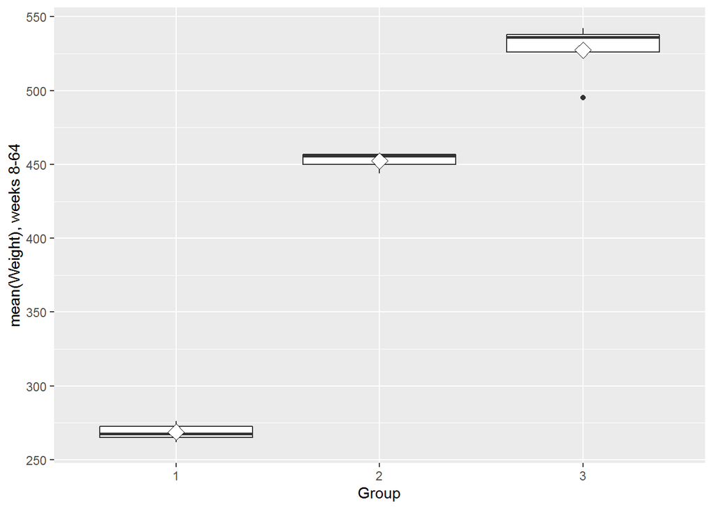

```r
RATSSL8S1 <- RATSSL8S %>%
  filter(mean < 550 & mean>250)
ggplot(RATSSL8S1, aes(x = Group, y = mean)) +
  geom_boxplot() +
  stat_summary(fun.y = "mean", geom = "point", shape=23, size=4, fill = "white") +
  scale_y_continuous(name = "mean(Weight), weeks 8-64")
```

T-test cannot be run because there are more than two groups. Anova is used instead.

```r
# Add the baseline from the original data as a new variable to the summary data
RATSSL8S2 <- RATSSL8S %>%
  mutate(baseline = RATS$Time1)
# Fit the linear model with the mean as the response
fit <- lm(mean ~ Group, data = RATSSL8S2)
# Compute the analysis of variance table for the fitted model with anova()
anova(fit)
```

```
## Analysis of Variance Table
##
## Response: mean
##           Df Sum Sq Mean Sq F value    Pr(>F)
## Group      2 238620  119310  88.525 2.679e-08 ***
## Residuals 13  17521    1348
## ---
## Signif. codes:  0 '***' 0.001 '**' 0.01 '*' 0.05 '.' 0.1 ' ' 1
```

```r
confint(fit)
```

```
##                2.5 %   97.5 %
## (Intercept) 236.9843 293.0657
## Group2      174.2071 271.3429
## Group3      213.9071 311.0429
```

P value is very low, under 0.05 meaning there is a significant relationship between group and weight. F value is high, which also is good. Confidence intervals for group 2 and group 3 are also shown. So in the end, nutrition group is very meaningful.